# latihan mpdw 4

# White Noise

Proses pembangkitan suatu model deret waktu diawali dengan membangkitkan data white noise yang tidak memiliki autokorelasi dengan nilai harapan tertentu dan ragam yang konstan.

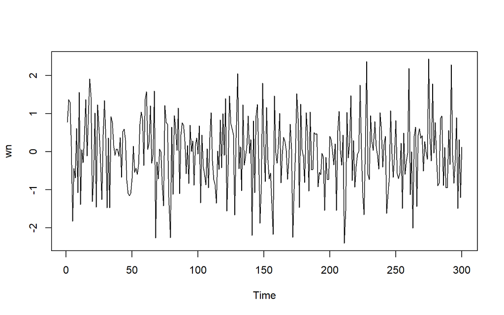

```r
set.seed(1016)
wn <- rnorm(300)
ts.plot(wn)
```

# MA(2)

Dalam kasus ini, akan dibangkitkan suatu data dengan model MA(2) sebanyak 300 data yang memiliki nilai $\theta_1 = 0.4$ dan $\theta_2 = 0.6$. Rumusan model tersebut adalah sebagai berikut

$$y_t = e_t-0.4e_{t-1}-0.6e_{t-2}$$

```r
set.seed(1016)
ma <- numeric(300)
wn <- rnorm(300)

ma[1] <- wn[1]
ma[2] <- wn[2] - 0.4 * wn[1]
```

```r
for(i in 3:300){
   ma[i] <- wn[i] - 0.4 * wn[i - 1] - 0.6 * wn[i - 2]
}
ma
```

```
##   [1]  0.7773787882  1.0623551686  0.2868262095 -1.1967348882 -2.6660001038
##   [6]  0.1967623364  0.5813575115  1.1548377992 -0.9045963316  1.6217800621
##  [11] -1.3708058421 -0.3289797764  0.5262174806  0.5264019767  1.3659542224
##  [16] -0.9207689647  0.2017260430  1.5884649492  0.0881096182 -3.0379641835
##  [21] -0.9714102496  2.0568334281 -1.4825571074  1.2047393369  1.0367649780
##  [26] -1.0590761997 -1.6334934040  0.9866033625  1.9198977369 -0.4490643758
##  [31] -2.4184471086  0.7387312825 -0.7380703088  1.2928871995  1.2796520693
##  [36] -0.6978083853 -0.6203166057  0.0115357145  0.0873417240 -0.1866411502
##  [41]  0.3820954329 -0.7495810598  0.5869357658  0.7896486128 -0.2616227921
##  [46] -1.2271215104 -0.9768917371 -0.2691704978  0.0266727670  0.4232648881
##  [51]  1.0846061267 -0.1760500017 -0.2995264972 -0.0994370344  0.1608424841
##  [56]  1.2135989680  0.9521769251  0.0038655041 -1.3244016896  1.0140735739
##  [61]  1.2407337017 -1.3975336130 -0.7334693453  1.0729020439 -0.9268633515
##  [66] -0.6987093585  1.8178819463 -2.8492592023 -0.3154204642  0.7522382979
##  [71]  0.5150263558  0.3970357354 -0.9090408652 -1.0717654832  2.3053063403
```

[output cut: 45 more lines]

Pembangkitan model MA(2) juga dapat dilakukan dengan menerapkan fungsi `arima.sim()`

```r
ma2 <- arima.sim(list(order=c(0,0,2), ma=c(0.4, 0.6)), n=300)
ma2
```

```
## Time Series:
## Start = 1
## End = 300
## Frequency = 1
##   [1]  0.541647106  0.721132375  0.504477057 -0.811160801 -1.374273442
##   [6] -1.326596174 -2.457632205  0.770116651 -1.444032735  0.292868575
##  [11] -1.034151266 -0.266230014  1.508248350  0.706143110  0.725603043
##  [16]  1.626170329  2.241865290  3.294337130  2.190214849  1.314415616
##  [21] -1.223607638 -0.199692827  0.241144961  1.087366702 -1.032050838
##  [26] -0.334499716  0.459643511  1.036068834  1.150295884 -0.130166018
##  [31] -0.856512466 -1.660441588 -0.674310302 -0.322509931  0.576779145
##  [36]  0.385903784  0.182339679 -0.961762624 -1.108707219  0.455615354
##  [41]  0.297310610 -0.102338479 -0.051552344 -0.410743043  0.681140713
##  [46]  0.602195527  1.321850441  0.693680575  2.415859282  2.018771133
##  [51]  2.828127431  1.011497644  1.644083489  0.014851729  1.491458582
```

[output cut: 49 more lines]

## Karakteristik MA(2)

## Plot Time Series

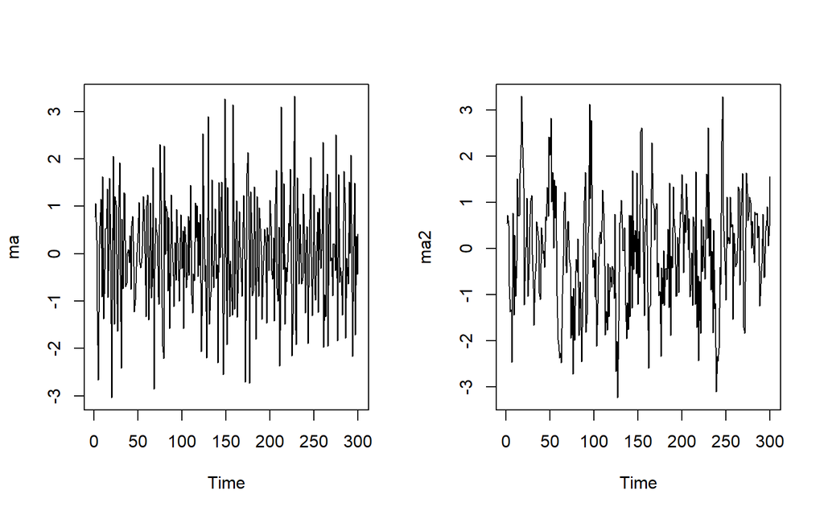

```r
par(mfrow = c(1, 2))
ts.plot(ma)
ts.plot(ma2)
```

Berdasarkan plot time series, terlihat bahwa baik hasil simulasi maupun dengan pembangkitan fungsi data MA(2) yang dibangkitkan stasioner dalam rataan

```r
par(mfrow = c(1, 1))
```

## Plot ACF

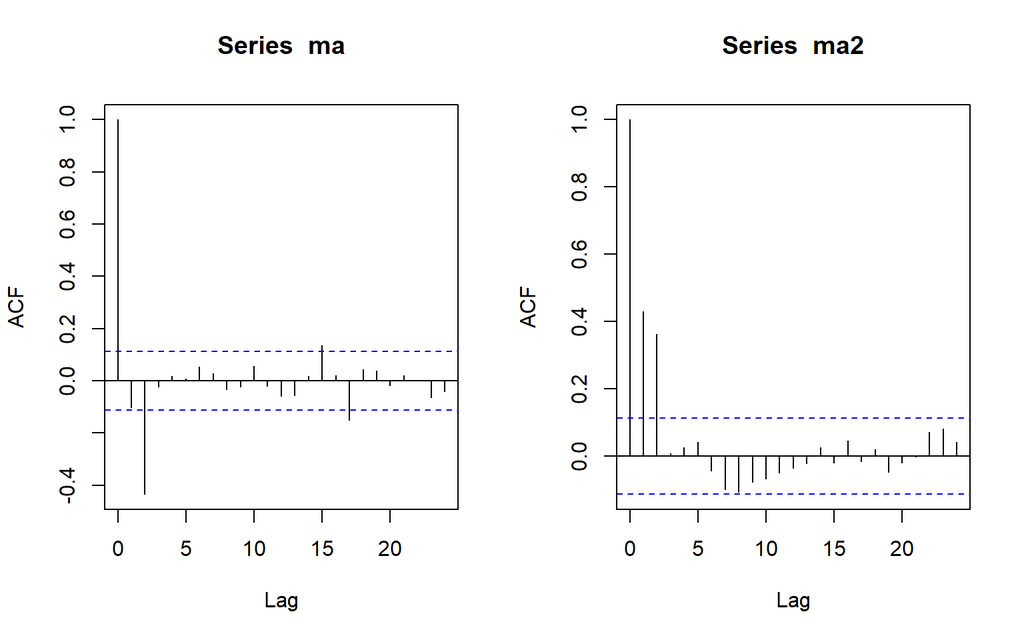

```r
par(mfrow = c(1, 2))
acf(ma)
acf(ma2)
```

Berdasarkan plot AFC tersebut baik hasil simulasi maupun dengan pembangkitan fungsi terlihat bahwa plot ACF *cuts off* di lag kedua

```r
par(mfrow = c(1, 1))
```

## Plot PACF

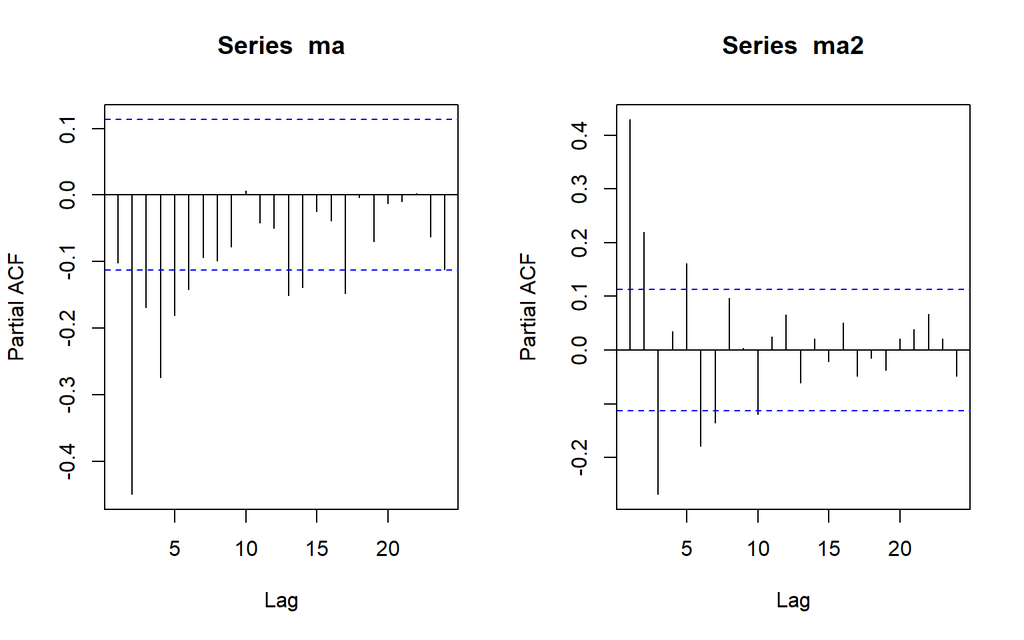

```r
par(mfrow = c(1, 2))
pacf(ma)
pacf(ma2)
```

Berdasarkan plot PACF tersebut baik hasil simulasi maupun dengan pembangkitan fungsi terlihat bahwa plot PACF cenderung *tails off* dan membentuk gelombang lembah karena nilai teta adalah positif

```r
par(mfrow = c(1, 1))
```

## Plot EACF

```r
TSA::eacf(ma)
```

```
## AR/MA
##   0 1 2 3 4 5 6 7 8 9 10 11 12 13
## 0 o x o o o o o o o o o  o  o  o
## 1 x x x o o o o o o o o  o  o  o
## 2 x x x o o o o o o o o  o  o  o
## 3 x x o x o o o o o o o  o  o  o
## 4 x o o x o o o o o o o  o  o  o
## 5 x x o x o x o o o o o  o  o  o
## 6 x x x o o x o o o o o  o  o  o
## 7 x x x x o o o o x o o  o  o  o
```

```r
TSA::eacf(ma2)
```

```
## AR/MA
##   0 1 2 3 4 5 6 7 8 9 10 11 12 13
## 0 x x o o o o o o o o o  o  o  o
## 1 x x x o o o o o o o o  o  o  o
## 2 x x x o o o o o o o o  o  o  o
## 3 x x o x o o o o o o o  o  o  o
## 4 x x x x o o o o o o o  o  o  o
## 5 x x x x o x o o o o o  o  o  o
## 6 x x x o x o o o o o o  o  o  o
## 7 x x x o x o o o o o o  o  o  o
```

Berdasarkan pola segitiga nol pada plot EACF, terlihat bahwa segitiga nol berada pada ordo AR(0) dan ordo MA(2)

## Scatterplot Antar Lag

### Korelasi antara $Y_t$ dengan $Y_{t-1}$

```r
yt_ma <- ma[-1]
yt_ma
```

```
##   [1]  1.0623551686  0.2868262095 -1.1967348882 -2.6660001038  0.1967623364
##   [6]  0.5813575115  1.1548377992 -0.9045963316  1.6217800621 -1.3708058421
##  [11] -0.3289797764  0.5262174806  0.5264019767  1.3659542224 -0.9207689647
##  [16]  0.2017260430  1.5884649492  0.0881096182 -3.0379641835 -0.9714102496
##  [21]  2.0568334281 -1.4825571074  1.2047393369  1.0367649780 -1.0590761997
##  [26] -1.6334934040  0.9866033625  1.9198977369 -0.4490643758 -2.4184471086
##  [31]  0.7387312825 -0.7380703088  1.2928871995  1.2796520693 -0.6978083853
##  [36] -0.6203166057  0.0115357145  0.0873417240 -0.1866411502  0.3820954329
##  [41] -0.7495810598  0.5869357658  0.7896486128 -0.2616227921 -1.2271215104
##  [46] -0.9768917371 -0.2691704978  0.0266727670  0.4232648881  1.0846061267
##  [51] -0.1760500017 -0.2995264972 -0.0994370344  0.1608424841  1.2135989680
##  [56]  0.9521769251  0.0038655041 -1.3244016896  1.0140735739  1.2407337017
##  [61] -1.3975336130 -0.7334693453  1.0729020439 -0.9268633515 -0.6987093585
##  [66]  1.8178819463 -2.8492592023 -0.3154204642  0.7522382979  0.5150263558
##  [71]  0.3970357354 -0.9090408652 -1.0717654832  2.3053063403  1.1307695165
```

[output cut: 45 more lines]

```r
yt_1_ma <- ma[-300]
yt_1_ma
```

```
##   [1]  0.7773787882  1.0623551686  0.2868262095 -1.1967348882 -2.6660001038
##   [6]  0.1967623364  0.5813575115  1.1548377992 -0.9045963316  1.6217800621
##  [11] -1.3708058421 -0.3289797764  0.5262174806  0.5264019767  1.3659542224
##  [16] -0.9207689647  0.2017260430  1.5884649492  0.0881096182 -3.0379641835
##  [21] -0.9714102496  2.0568334281 -1.4825571074  1.2047393369  1.0367649780
##  [26] -1.0590761997 -1.6334934040  0.9866033625  1.9198977369 -0.4490643758
##  [31] -2.4184471086  0.7387312825 -0.7380703088  1.2928871995  1.2796520693
##  [36] -0.6978083853 -0.6203166057  0.0115357145  0.0873417240 -0.1866411502
##  [41]  0.3820954329 -0.7495810598  0.5869357658  0.7896486128 -0.2616227921
##  [46] -1.2271215104 -0.9768917371 -0.2691704978  0.0266727670  0.4232648881
##  [51]  1.0846061267 -0.1760500017 -0.2995264972 -0.0994370344  0.1608424841
##  [56]  1.2135989680  0.9521769251  0.0038655041 -1.3244016896  1.0140735739
##  [61]  1.2407337017 -1.3975336130 -0.7334693453  1.0729020439 -0.9268633515
##  [66] -0.6987093585  1.8178819463 -2.8492592023 -0.3154204642  0.7522382979
##  [71]  0.5150263558  0.3970357354 -0.9090408652 -1.0717654832  2.3053063403
```

[output cut: 45 more lines]

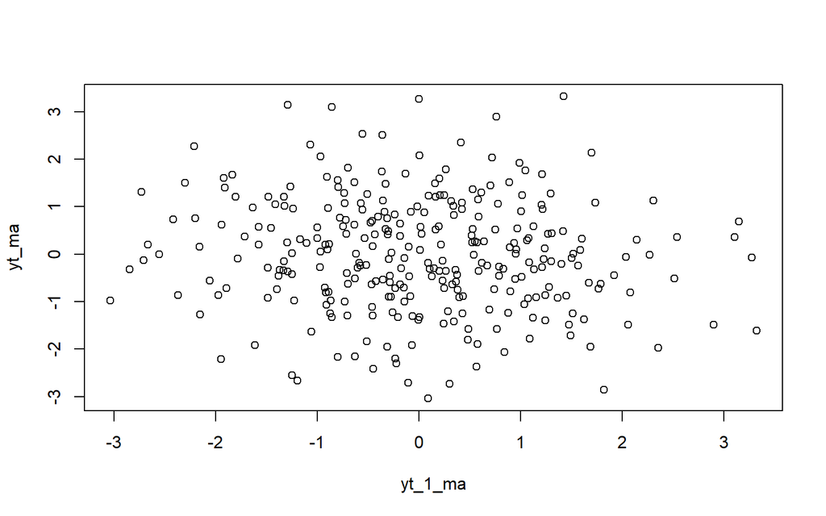

```r
plot(y=yt_ma,x=yt_1_ma)
```

Berdasarkan scatterplot tersebut, terlihat bahwa terdapat hubungan negatif antara $Y_t$ dengan $Y_{t-1}$.

```r
cor(yt_ma,yt_1_ma)
```

```
## [1] -0.1020832
```

Korelasi antara $Y_t$ dengan $Y_{t-1}$ dari hasil simulasi jika dibulatkan akan mendekati perhitungan teoritis yaitu

$$\rho_1=\frac{-\theta_1+\theta_1\theta_2}{1+\theta_1^2+\theta_2^2}=\frac{-0.4+0.4\times0.6}{1+0.4^2+0.6^2}=-0.105$$

### Korelasi antara $Y_t$ dengan $Y_{t-2}$

```r
yt_ma2 <- ma[-c(1,2)]
yt_ma2
```

```
##   [1]  0.2868262095 -1.1967348882 -2.6660001038  0.1967623364  0.5813575115
##   [6]  1.1548377992 -0.9045963316  1.6217800621 -1.3708058421 -0.3289797764
##  [11]  0.5262174806  0.5264019767  1.3659542224 -0.9207689647  0.2017260430
##  [16]  1.5884649492  0.0881096182 -3.0379641835 -0.9714102496  2.0568334281
##  [21] -1.4825571074  1.2047393369  1.0367649780 -1.0590761997 -1.6334934040
##  [26]  0.9866033625  1.9198977369 -0.4490643758 -2.4184471086  0.7387312825
##  [31] -0.7380703088  1.2928871995  1.2796520693 -0.6978083853 -0.6203166057
##  [36]  0.0115357145  0.0873417240 -0.1866411502  0.3820954329 -0.7495810598
##  [41]  0.5869357658  0.7896486128 -0.2616227921 -1.2271215104 -0.9768917371
##  [46] -0.2691704978  0.0266727670  0.4232648881  1.0846061267 -0.1760500017
##  [51] -0.2995264972 -0.0994370344  0.1608424841  1.2135989680  0.9521769251
##  [56]  0.0038655041 -1.3244016896  1.0140735739  1.2407337017 -1.3975336130
##  [61] -0.7334693453  1.0729020439 -0.9268633515 -0.6987093585  1.8178819463
##  [66] -2.8492592023 -0.3154204642  0.7522382979  0.5150263558  0.3970357354
##  [71] -0.9090408652 -1.0717654832  2.3053063403  1.1307695165 -0.3158550339
```

[output cut: 45 more lines]

```r
yt_2_ma <- ma[-c(299,300)]
yt_2_ma
```

```
##   [1]  0.7773787882  1.0623551686  0.2868262095 -1.1967348882 -2.6660001038
##   [6]  0.1967623364  0.5813575115  1.1548377992 -0.9045963316  1.6217800621
##  [11] -1.3708058421 -0.3289797764  0.5262174806  0.5264019767  1.3659542224
##  [16] -0.9207689647  0.2017260430  1.5884649492  0.0881096182 -3.0379641835
##  [21] -0.9714102496  2.0568334281 -1.4825571074  1.2047393369  1.0367649780
##  [26] -1.0590761997 -1.6334934040  0.9866033625  1.9198977369 -0.4490643758
##  [31] -2.4184471086  0.7387312825 -0.7380703088  1.2928871995  1.2796520693
##  [36] -0.6978083853 -0.6203166057  0.0115357145  0.0873417240 -0.1866411502
##  [41]  0.3820954329 -0.7495810598  0.5869357658  0.7896486128 -0.2616227921
##  [46] -1.2271215104 -0.9768917371 -0.2691704978  0.0266727670  0.4232648881
##  [51]  1.0846061267 -0.1760500017 -0.2995264972 -0.0994370344  0.1608424841
##  [56]  1.2135989680  0.9521769251  0.0038655041 -1.3244016896  1.0140735739
##  [61]  1.2407337017 -1.3975336130 -0.7334693453  1.0729020439 -0.9268633515
##  [66] -0.6987093585  1.8178819463 -2.8492592023 -0.3154204642  0.7522382979
##  [71]  0.5150263558  0.3970357354 -0.9090408652 -1.0717654832  2.3053063403
```

[output cut: 45 more lines]

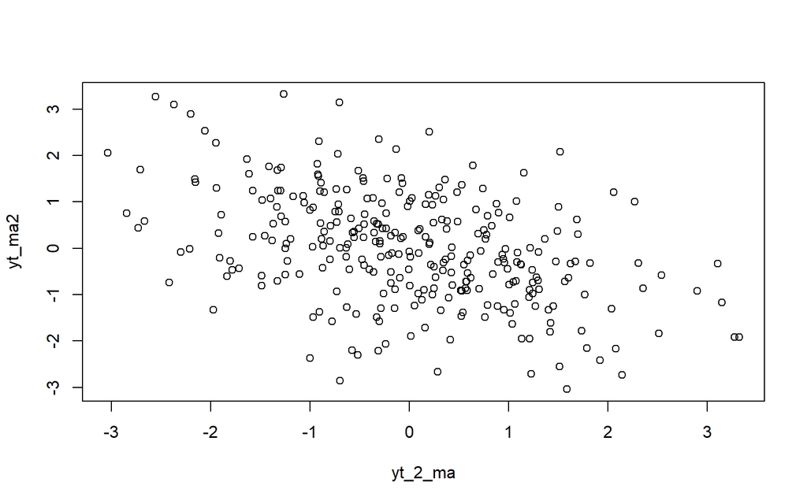

```r
plot(y=yt_ma2,x=yt_2_ma)
```

Berdasarkan scatterplot tersebut, terlihat bahwa terdapat hubungan negatif antara $Y_t$ dengan $Y_{t-2}$.

```r
cor(yt_ma2,yt_2_ma)
```

```
## [1] -0.4355584
```

Korelasi antara $Y_t$ dengan $Y_{t-2}$ dari hasil simulasi tergolong mendekati perhitungan teoritis yaitu

$$\rho_2=\frac{-\theta_2}{1+\theta_1^2+\theta_2^2}=\frac{-0.6}{1+0.4^2+0.6^2}=-0.394$$

### Korelasi antara $Y_t$ dengan $Y_{t-3}$

```r
yt_ma3 <- ma[-c(1,2,3)]
yt_ma3
```

```
##   [1] -1.1967348882 -2.6660001038  0.1967623364  0.5813575115  1.1548377992
##   [6] -0.9045963316  1.6217800621 -1.3708058421 -0.3289797764  0.5262174806
##  [11]  0.5264019767  1.3659542224 -0.9207689647  0.2017260430  1.5884649492
##  [16]  0.0881096182 -3.0379641835 -0.9714102496  2.0568334281 -1.4825571074
##  [21]  1.2047393369  1.0367649780 -1.0590761997 -1.6334934040  0.9866033625
##  [26]  1.9198977369 -0.4490643758 -2.4184471086  0.7387312825 -0.7380703088
##  [31]  1.2928871995  1.2796520693 -0.6978083853 -0.6203166057  0.0115357145
##  [36]  0.0873417240 -0.1866411502  0.3820954329 -0.7495810598  0.5869357658
##  [41]  0.7896486128 -0.2616227921 -1.2271215104 -0.9768917371 -0.2691704978
##  [46]  0.0266727670  0.4232648881  1.0846061267 -0.1760500017 -0.2995264972
##  [51] -0.0994370344  0.1608424841  1.2135989680  0.9521769251  0.0038655041
##  [56] -1.3244016896  1.0140735739  1.2407337017 -1.3975336130 -0.7334693453
##  [61]  1.0729020439 -0.9268633515 -0.6987093585  1.8178819463 -2.8492592023
##  [66] -0.3154204642  0.7522382979  0.5150263558  0.3970357354 -0.9090408652
##  [71] -1.0717654832  2.3053063403  1.1307695165 -0.3158550339 -1.9489921402
```

[output cut: 45 more lines]

```r
yt_3_ma <- ma[-c(298, 299,300)]
yt_3_ma
```

```
##   [1]  0.7773787882  1.0623551686  0.2868262095 -1.1967348882 -2.6660001038
##   [6]  0.1967623364  0.5813575115  1.1548377992 -0.9045963316  1.6217800621
##  [11] -1.3708058421 -0.3289797764  0.5262174806  0.5264019767  1.3659542224
##  [16] -0.9207689647  0.2017260430  1.5884649492  0.0881096182 -3.0379641835
##  [21] -0.9714102496  2.0568334281 -1.4825571074  1.2047393369  1.0367649780
##  [26] -1.0590761997 -1.6334934040  0.9866033625  1.9198977369 -0.4490643758
##  [31] -2.4184471086  0.7387312825 -0.7380703088  1.2928871995  1.2796520693
##  [36] -0.6978083853 -0.6203166057  0.0115357145  0.0873417240 -0.1866411502
##  [41]  0.3820954329 -0.7495810598  0.5869357658  0.7896486128 -0.2616227921
##  [46] -1.2271215104 -0.9768917371 -0.2691704978  0.0266727670  0.4232648881
##  [51]  1.0846061267 -0.1760500017 -0.2995264972 -0.0994370344  0.1608424841
##  [56]  1.2135989680  0.9521769251  0.0038655041 -1.3244016896  1.0140735739
##  [61]  1.2407337017 -1.3975336130 -0.7334693453  1.0729020439 -0.9268633515
##  [66] -0.6987093585  1.8178819463 -2.8492592023 -0.3154204642  0.7522382979
##  [71]  0.5150263558  0.3970357354 -0.9090408652 -1.0717654832  2.3053063403
```

[output cut: 45 more lines]

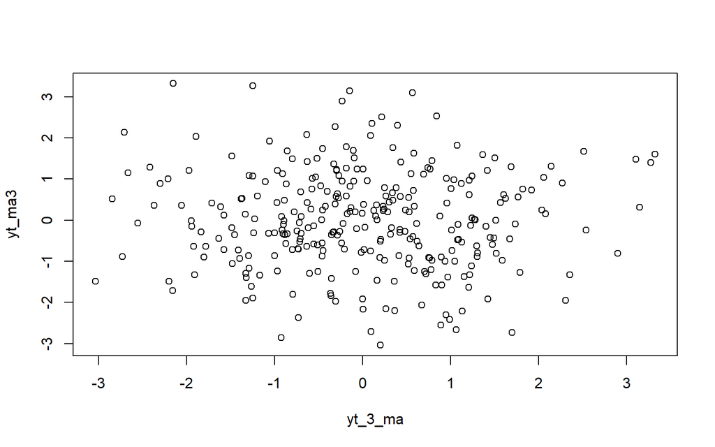

```r
plot(y=yt_ma3,x=yt_3_ma)
```

Berdasarkan scatterplot tersebut, terlihat bahwa $Y_t$ dan $Y_{t-3}$ sudah menunjukkan pola yang tidak beraturan atau bisa disebut tidak berpola.

```r
cor(yt_ma3,yt_3_ma)
```

```
## [1] -0.02327519
```

Korelasi antara $Y_t$ dengan $Y_{t-3}$ dari hasil simulasi mendekati nilai teoritis yang menyatakan bahwa $\rho_k=0$ untuk k>q

# AR(2)

Dalam kasus ini, akan dibangkitkan suatu data dengan model AR(2) sebanyak 300 data yang memiliki nilai $\phi_1 = 0.5$ dan $\phi_2 = 0.2$. Rumusan model tersebut adalah sebagai berikut

$$Y_t = e_t+0.5Y_{t-1}+0.2Y_{t-2}$$

```r
set.seed(1016)
wn <- rnorm(300)

ar <- numeric(300)
ar[1] <- wn[1]
ar[2] <- wn[2] + 0.5 * ar[1]
```

```r
for (i in 3:300) {
  ar[i] <- wn[i] + 0.5 * ar[i-1] + 0.2 * ar[i-2]
}
ar
```

```
##   [1]  0.777378788  1.761996078  2.339049953  1.670203776 -0.522230698
##   [6] -0.371401537 -0.981605720  0.046574941 -1.247842049  0.944245541
##  [11] -1.169595876 -0.346477754 -0.696442283  0.022854237  1.240670717
##  [16]  0.515772621  1.485212296  2.760422208  3.118742901  0.798884365
##  [21]  0.391645505  1.372272034 -0.690350181  1.162095979  1.099980417
##  [26]  0.725824188 -0.679017835  0.253537747  1.332860167  1.073560298
##  [31] -0.667388944  0.245306019 -1.485624392  0.227789421  0.580158300
##  [36]  0.496108284  0.265990776  0.300797499  0.259513795  0.066790276
##  [41]  0.451693015 -0.437694123  0.407504904  0.714128374  0.737716292
##  [46] -0.237028392 -1.067856885 -1.738486326 -2.177134223 -2.145018685
##  [51] -1.363423594 -1.654213083 -1.530009221 -1.693469975 -1.489074223
##  [56] -0.362740744  0.559385418  1.058732536  0.280619233  1.732832836
##  [61]  2.499210180  1.657772038  1.565900811  2.319236188  1.170131108
##  [66]  0.951975399  2.307520621 -0.924263568 -0.264911687 -1.031835244
##  [71] -0.498254695 -0.458916568 -1.197131798 -2.111377029 -0.079033205
```

[output cut: 45 more lines]

Pembangkitan model AR(2) juga dapat dilakukan dengan menerapkan fungsi `arima.sim()`

```r
ar2 <- arima.sim(list(order=c(2,0,0), ar=c(0.5,0.2)), n=300)
ar2
```

```
## Time Series:
## Start = 1
## End = 300
## Frequency = 1
##   [1]  1.346910758 -0.885790074 -0.038979388  1.320970812  1.000990855
##   [6]  0.865093831  0.253436576 -0.465294552 -1.308803800 -0.512014613
##  [11] -0.258350173  0.100166260  0.095968436  0.012288451 -0.972666308
##  [16] -1.159943583  0.550340081  0.216194751 -0.748285539 -0.099683848
##  [21] -0.122859505  0.430386397  0.542131941  1.231337682  0.857191645
##  [26]  2.512967415  2.631593697  3.062186664  1.849188186  2.518126669
##  [31]  1.376248935  2.195612052  1.786802661  1.919966605 -0.187072075
##  [36] -1.436000201 -1.225617089 -2.044367797 -2.797564510 -2.982661151
##  [41] -1.650101096 -1.035195745 -0.425748877  0.393510663 -0.843414694
##  [46] -0.972215709  0.738865595  0.587141386 -0.787601702 -0.418141240
##  [51] -1.514487775 -1.330724760 -2.799138199 -1.498946726 -2.260886965
```

[output cut: 49 more lines]

## Karakteristik AR(2)

## Plot Time Series

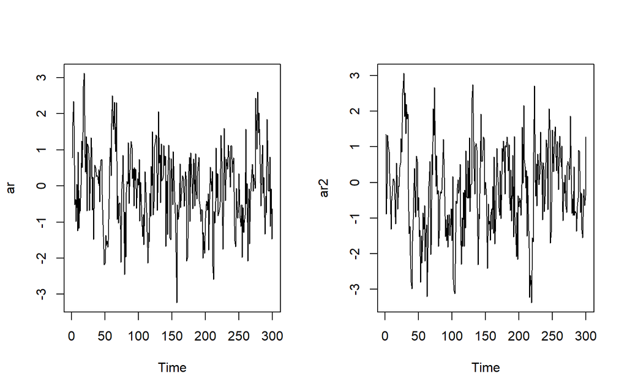

```r
par(mfrow = c(1, 2))
ts.plot(ar)
ts.plot(ar2)
```

Berdasarkan plot time series tersebut baik hasil simulasi maupun dengan pembangkitan fungsi terlihat bahwa data cenderung stasioner pada rataan

```r
par(mfrow = c(1, 1))
```

## Plot ACF

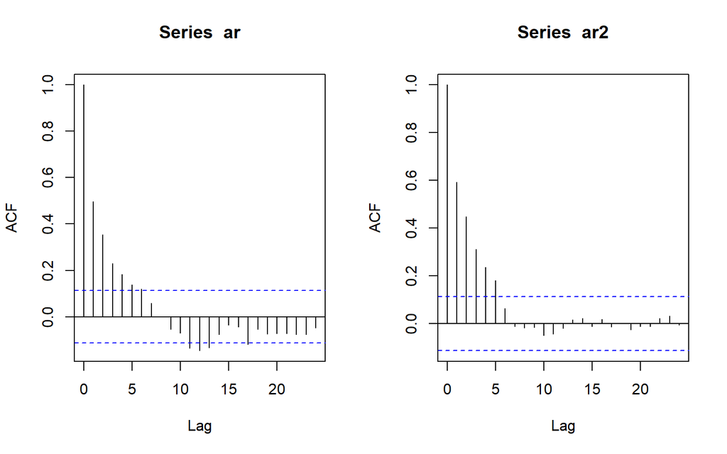

```r
par(mfrow = c(1, 2))
acf(ar)
acf(ar2)
```

Berdasarkan plot ACF tersebut baik hasil simulasi maupun dengan pembangkitan fungsi terlihat bahwa plot ACF cenderung *tails off*

```r
par(mfrow = c(1, 1))
```

## Plot PACF

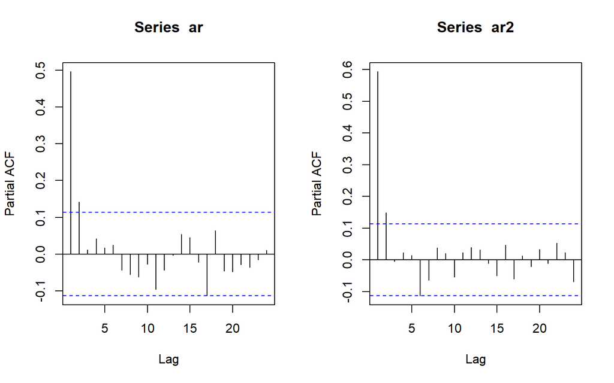

```r
par(mfrow = c(1, 2))
pacf(ar)
pacf(ar2)
```

Berdasarkan plot PACF tersebut baik hasil simulasi maupun dengan pembangkitan fungsi terlihat bahwa plot PACF *cuts off* pada lag kedua

```r
par(mfrow = c(1, 1))
```

## Plot EACF

```r
TSA::eacf(ar)
```

```
## AR/MA
##   0 1 2 3 4 5 6 7 8 9 10 11 12 13
## 0 x x x x x x o o o o x  x  x  o
## 1 x o o o o o o o o o o  o  o  o
## 2 o x o o o o o o o o o  o  o  o
## 3 x x o o o o o o o o o  o  o  o
## 4 x x o o o o o o o o o  o  o  o
## 5 x x x o o o o o o o o  o  o  o
## 6 x x x x o o o o o o o  o  o  o
## 7 x o x x x o o o o o o  o  o  o
```

```r
TSA::eacf(ar2)
```

```
## AR/MA
##   0 1 2 3 4 5 6 7 8 9 10 11 12 13
## 0 x x x x x o o o o o o  o  o  o
## 1 x o o o x o o o o o o  o  o  o
## 2 o o o o x o o o o o o  o  o  o
## 3 x x o o o o o o o o o  o  o  o
## 4 x x o o o o o o o o o  o  o  o
## 5 x x o x x o o o o o o  o  o  o
## 6 x x x o x o o o o o o  o  o  o
## 7 x x x o x o o o o o o  o  o  o
```

Berdasarkan pola segitiga nol pada plot EACF, terlihat bahwa segitiga nol berada pada ordo AR(1) dan ordo MA(1)

## Scatterplot Antar Lag

### Korelasi antara $Y_t$ dengan $Y_{t-1}$

```r
yt_ar <- ar[-1]
yt_ar
```

```
##   [1]  1.761996078  2.339049953  1.670203776 -0.522230698 -0.371401537
##   [6] -0.981605720  0.046574941 -1.247842049  0.944245541 -1.169595876
##  [11] -0.346477754 -0.696442283  0.022854237  1.240670717  0.515772621
##  [16]  1.485212296  2.760422208  3.118742901  0.798884365  0.391645505
##  [21]  1.372272034 -0.690350181  1.162095979  1.099980417  0.725824188
##  [26] -0.679017835  0.253537747  1.332860167  1.073560298 -0.667388944
##  [31]  0.245306019 -1.485624392  0.227789421  0.580158300  0.496108284
##  [36]  0.265990776  0.300797499  0.259513795  0.066790276  0.451693015
##  [41] -0.437694123  0.407504904  0.714128374  0.737716292 -0.237028392
##  [46] -1.067856885 -1.738486326 -2.177134223 -2.145018685 -1.363423594
##  [51] -1.654213083 -1.530009221 -1.693469975 -1.489074223 -0.362740744
##  [56]  0.559385418  1.058732536  0.280619233  1.732832836  2.499210180
##  [61]  1.657772038  1.565900811  2.319236188  1.170131108  0.951975399
##  [66]  2.307520621 -0.924263568 -0.264911687 -1.031835244 -0.498254695
##  [71] -0.458916568 -1.197131798 -2.111377029 -0.079033205  0.302793486
```

[output cut: 45 more lines]

```r
yt_1_ar <- ar[-300]
yt_1_ar
```

```
##   [1]  0.777378788  1.761996078  2.339049953  1.670203776 -0.522230698
##   [6] -0.371401537 -0.981605720  0.046574941 -1.247842049  0.944245541
##  [11] -1.169595876 -0.346477754 -0.696442283  0.022854237  1.240670717
##  [16]  0.515772621  1.485212296  2.760422208  3.118742901  0.798884365
##  [21]  0.391645505  1.372272034 -0.690350181  1.162095979  1.099980417
##  [26]  0.725824188 -0.679017835  0.253537747  1.332860167  1.073560298
##  [31] -0.667388944  0.245306019 -1.485624392  0.227789421  0.580158300
##  [36]  0.496108284  0.265990776  0.300797499  0.259513795  0.066790276
##  [41]  0.451693015 -0.437694123  0.407504904  0.714128374  0.737716292
##  [46] -0.237028392 -1.067856885 -1.738486326 -2.177134223 -2.145018685
##  [51] -1.363423594 -1.654213083 -1.530009221 -1.693469975 -1.489074223
##  [56] -0.362740744  0.559385418  1.058732536  0.280619233  1.732832836
##  [61]  2.499210180  1.657772038  1.565900811  2.319236188  1.170131108
##  [66]  0.951975399  2.307520621 -0.924263568 -0.264911687 -1.031835244
##  [71] -0.498254695 -0.458916568 -1.197131798 -2.111377029 -0.079033205
```

[output cut: 45 more lines]

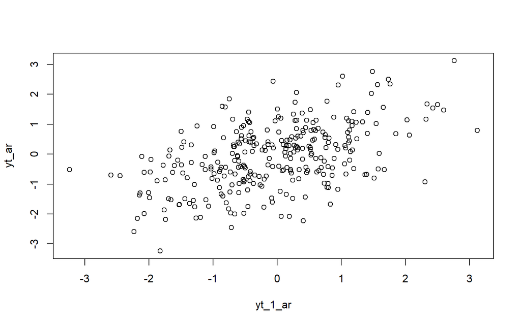

```r
plot(y=yt_ar,x=yt_1_ar)
```

Berdasarkan scatterplot tersebut, terlihat bahwa terdapat hubungan positif antara $Y_t$ dengan $Y_{t-1}$.

```r
cor(yt_ar,yt_1_ar)
```

```
## [1] 0.4967908
```

Korelasi antara $Y_t$ dengan $Y_{t-1}$ dari hasil simulasi cukup jauh dari perhitungan teoritis yaitu

$$\rho_1=\frac{\phi_1}{1-\phi_2}=\frac{0.5}{1-0.2}=0.625$$

### Korelasi antara $Y_t$ dengan $Y_{t-2}$

```r
yt_ar2 <- ar[-c(1,2)]
yt_ar2
```

```
##   [1]  2.339049953  1.670203776 -0.522230698 -0.371401537 -0.981605720
##   [6]  0.046574941 -1.247842049  0.944245541 -1.169595876 -0.346477754
##  [11] -0.696442283  0.022854237  1.240670717  0.515772621  1.485212296
##  [16]  2.760422208  3.118742901  0.798884365  0.391645505  1.372272034
##  [21] -0.690350181  1.162095979  1.099980417  0.725824188 -0.679017835
##  [26]  0.253537747  1.332860167  1.073560298 -0.667388944  0.245306019
##  [31] -1.485624392  0.227789421  0.580158300  0.496108284  0.265990776
##  [36]  0.300797499  0.259513795  0.066790276  0.451693015 -0.437694123
##  [41]  0.407504904  0.714128374  0.737716292 -0.237028392 -1.067856885
##  [46] -1.738486326 -2.177134223 -2.145018685 -1.363423594 -1.654213083
##  [51] -1.530009221 -1.693469975 -1.489074223 -0.362740744  0.559385418
##  [56]  1.058732536  0.280619233  1.732832836  2.499210180  1.657772038
##  [61]  1.565900811  2.319236188  1.170131108  0.951975399  2.307520621
##  [66] -0.924263568 -0.264911687 -1.031835244 -0.498254695 -0.458916568
##  [71] -1.197131798 -2.111377029 -0.079033205  0.302793486  0.855218267
```

[output cut: 45 more lines]

```r
yt_2_ar <- ar[-c(299,300)]
yt_2_ar
```

```
##   [1]  0.777378788  1.761996078  2.339049953  1.670203776 -0.522230698
##   [6] -0.371401537 -0.981605720  0.046574941 -1.247842049  0.944245541
##  [11] -1.169595876 -0.346477754 -0.696442283  0.022854237  1.240670717
##  [16]  0.515772621  1.485212296  2.760422208  3.118742901  0.798884365
##  [21]  0.391645505  1.372272034 -0.690350181  1.162095979  1.099980417
##  [26]  0.725824188 -0.679017835  0.253537747  1.332860167  1.073560298
##  [31] -0.667388944  0.245306019 -1.485624392  0.227789421  0.580158300
##  [36]  0.496108284  0.265990776  0.300797499  0.259513795  0.066790276
##  [41]  0.451693015 -0.437694123  0.407504904  0.714128374  0.737716292
##  [46] -0.237028392 -1.067856885 -1.738486326 -2.177134223 -2.145018685
##  [51] -1.363423594 -1.654213083 -1.530009221 -1.693469975 -1.489074223
##  [56] -0.362740744  0.559385418  1.058732536  0.280619233  1.732832836
##  [61]  2.499210180  1.657772038  1.565900811  2.319236188  1.170131108
##  [66]  0.951975399  2.307520621 -0.924263568 -0.264911687 -1.031835244
##  [71] -0.498254695 -0.458916568 -1.197131798 -2.111377029 -0.079033205
```

[output cut: 45 more lines]

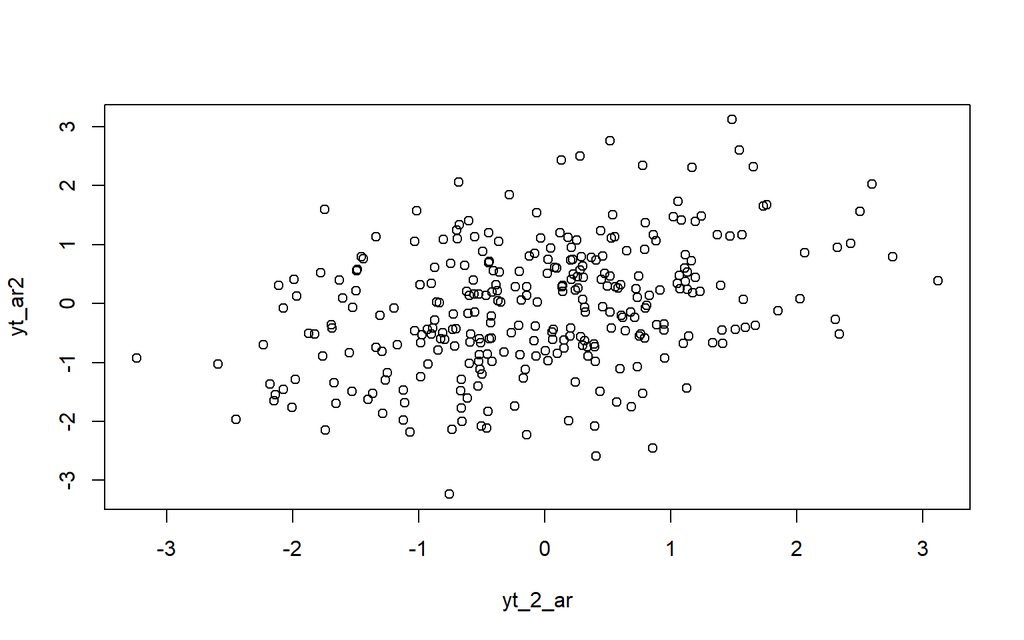

```r
plot(y=yt_ar2,x=yt_2_ar)
```

Berdasarkan scatterplot tersebut, terlihat bahwa terdapat hubungan positif antara $Y_t$ dengan $Y_{t-2}$.

```r
cor(yt_ar2,yt_2_ar)
```

```
## [1] 0.3567412
```

Korelasi antara $Y_t$ dengan $Y_{t-2}$ dari hasil simulasi cukup jauh dari perhitungan teoritis yaitu

$$\rho_2=\phi_1\rho_{k-1}+\phi_2\rho_{k-2}=\frac{\phi_2(1-\phi_2)+\phi_1^2}{1-\phi_2}=\frac{0.2(1-0.2)+0.5^2}{1-0.2}=0.5125$$

### Korelasi antara $Y_t$ dengan $Y_{t-3}$

```r
yt_ar3 <- ar[-c(1,2,3)]
yt_ar3
```

```
##   [1]  1.670203776 -0.522230698 -0.371401537 -0.981605720  0.046574941
##   [6] -1.247842049  0.944245541 -1.169595876 -0.346477754 -0.696442283
##  [11]  0.022854237  1.240670717  0.515772621  1.485212296  2.760422208
##  [16]  3.118742901  0.798884365  0.391645505  1.372272034 -0.690350181
##  [21]  1.162095979  1.099980417  0.725824188 -0.679017835  0.253537747
##  [26]  1.332860167  1.073560298 -0.667388944  0.245306019 -1.485624392
##  [31]  0.227789421  0.580158300  0.496108284  0.265990776  0.300797499
##  [36]  0.259513795  0.066790276  0.451693015 -0.437694123  0.407504904
##  [41]  0.714128374  0.737716292 -0.237028392 -1.067856885 -1.738486326
##  [46] -2.177134223 -2.145018685 -1.363423594 -1.654213083 -1.530009221
##  [51] -1.693469975 -1.489074223 -0.362740744  0.559385418  1.058732536
##  [56]  0.280619233  1.732832836  2.499210180  1.657772038  1.565900811
##  [61]  2.319236188  1.170131108  0.951975399  2.307520621 -0.924263568
##  [66] -0.264911687 -1.031835244 -0.498254695 -0.458916568 -1.197131798
##  [71] -2.111377029 -0.079033205  0.302793486  0.855218267 -0.714221747
```

[output cut: 45 more lines]

```r
yt_3_ar <- ar[-c(298,299,300)]
yt_3_ar
```

```
##   [1]  0.777378788  1.761996078  2.339049953  1.670203776 -0.522230698
##   [6] -0.371401537 -0.981605720  0.046574941 -1.247842049  0.944245541
##  [11] -1.169595876 -0.346477754 -0.696442283  0.022854237  1.240670717
##  [16]  0.515772621  1.485212296  2.760422208  3.118742901  0.798884365
##  [21]  0.391645505  1.372272034 -0.690350181  1.162095979  1.099980417
##  [26]  0.725824188 -0.679017835  0.253537747  1.332860167  1.073560298
##  [31] -0.667388944  0.245306019 -1.485624392  0.227789421  0.580158300
##  [36]  0.496108284  0.265990776  0.300797499  0.259513795  0.066790276
##  [41]  0.451693015 -0.437694123  0.407504904  0.714128374  0.737716292
##  [46] -0.237028392 -1.067856885 -1.738486326 -2.177134223 -2.145018685
##  [51] -1.363423594 -1.654213083 -1.530009221 -1.693469975 -1.489074223
##  [56] -0.362740744  0.559385418  1.058732536  0.280619233  1.732832836
##  [61]  2.499210180  1.657772038  1.565900811  2.319236188  1.170131108
##  [66]  0.951975399  2.307520621 -0.924263568 -0.264911687 -1.031835244
##  [71] -0.498254695 -0.458916568 -1.197131798 -2.111377029 -0.079033205
```

[output cut: 45 more lines]

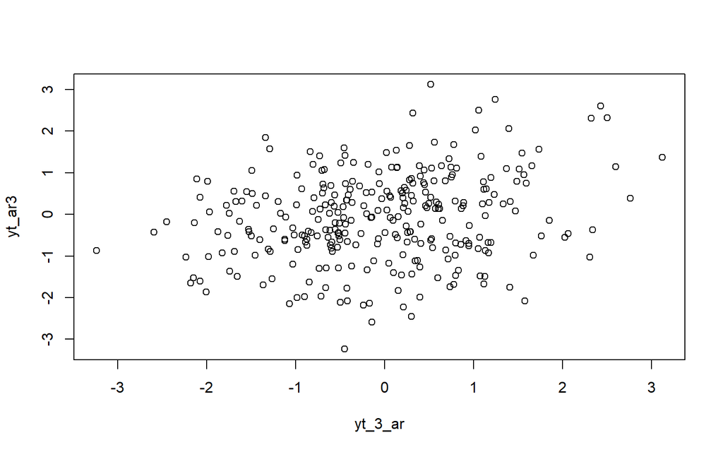

```r
plot(y=yt_ar3,x=yt_3_ar)
```

Berdasarkan scatterplot tersebut, terlihat bahwa terdapat hubungan positif antara $Y_t$ dengan $Y_{t-3}$.

```r
cor(yt_ar3,yt_3_ar)
```

```
## [1] 0.2340959
```

Korelasi antara $Y_t$ dengan $Y_{t-3}$ dari hasil simulasi cukup jauh dari perhitungan teoritis yaitu

$$\rho_3=\phi_1\rho_{k-1}+\phi_2\rho_{k-2}=\phi_1\rho_2+\phi_2\rho_1=0.5\times0.5125+0.2\times0.625=0.38125$$

# ARMA(2,2)

Dalam kasus ini, akan dibangkitkan suatu data dengan model ARMA(2,2) sebanyak 300 data yang memiliki nilai $\theta_1 = 0.4$, $\theta_2 = 0.6$ serta $\phi_1 = 0.5$ dan $\phi_2 = 0.2$. Rumusan model tersebut adalah sebagai berikut

$$Y_t =
0.5Y_{t-1}+0.2Y_{t-2}+e_t-0.4_{t-1}-0.6_{t-2}$$

```r
set.seed(1016)
theta1 = 0.4
theta2 = 0.6
phi1 = 0.5
phi2 = 0.2

y.arma=c(1:300)
for (i in 3:300){y.arma[i] = phi1*y.arma[i-1] + phi2*y.arma[i-2] +
                 wn[i] - theta1*wn[i-1] - theta2*wn[i-2]}
y.arma
```

```
##   [1]  1.000000000  2.000000000  1.486826210 -0.053321783 -2.395295754
##   [6] -1.011549897 -0.403476588  0.750789526 -0.609896886  1.466989524
##  [11] -0.759290457 -0.415227100  0.166745839  0.526729476  1.662668128
##  [16]  0.015910995  0.542215166  1.862754731  1.127930017 -2.101448229
##  [21] -1.796548361  0.738269602 -1.472731979  0.616027268  1.050232216
##  [26] -0.410754638 -1.628824280  0.090040295  1.639153029  0.388520197
##  [31] -1.896356404 -0.131742880 -1.183213030  0.674932109  1.380475518
##  [36]  0.127415795 -0.280513605 -0.103237929 -0.020379961 -0.217478717
##  [41]  0.269280082 -0.658436762  0.311573401  0.813747961  0.207565869
##  [46] -0.960588984 -1.415673055 -1.169124822 -0.841024255 -0.231072204
##  [51]  0.800865174  0.178168144 -0.050269390 -0.088938101  0.106319556
##  [56]  1.248971126  1.597926399  1.052622929 -0.478504945  0.985345687
##  [61]  1.637705556 -0.381611698 -0.596734083  0.698212663 -0.697103837
##  [66] -0.907618744  1.224651807 -2.418457048 -1.279718627 -0.371312425
##  [71]  0.073426418  0.359486459 -0.714612352 -1.357174367  1.483796686
```

[output cut: 45 more lines]

Pembangkitan model ARMA(2,2) juga dapat dilakukan dengan menerapkan fungsi `arima.sim()`

```r
arma22 <- arima.sim(list(order=c(2,0,2), ar = c(0.5,0.2), ma = c(0.4,0.6)), n=300)
arma22
```

```
## Time Series:
## Start = 1
## End = 300
## Frequency = 1
##   [1]  0.415963357  1.025750189  1.757977472  0.561103630  0.621992889
##   [6] -1.788311745 -0.219563668 -0.220319318  0.864678492  0.812401937
##  [11]  0.704761860  0.539353374  0.351017966  0.634074462 -0.216975487
##  [16]  0.503418108  0.614494837  1.267856081  0.486524093 -0.720046896
##  [21] -2.307852541 -3.513247783 -4.058967904 -3.527714448 -3.486595902
##  [26] -3.009750265 -3.298002775 -3.084468708 -1.974453152 -0.479155972
##  [31]  1.064841831  1.039743174  2.480319803  3.360714665  3.697155667
##  [36]  3.728535624  3.940259651  3.037366006  2.811569506  3.390389408
##  [41]  0.569929892  0.749895238 -1.692358076 -1.069935817 -1.277319602
##  [46] -1.679651249 -2.865579694 -1.641863099 -0.995646016  0.928915736
##  [51] -0.190458350 -2.220286429 -2.130840592 -3.726405938 -1.404770697
```

[output cut: 49 more lines]

## Karakteristik ARMA(2,2)

## Plot Time Series

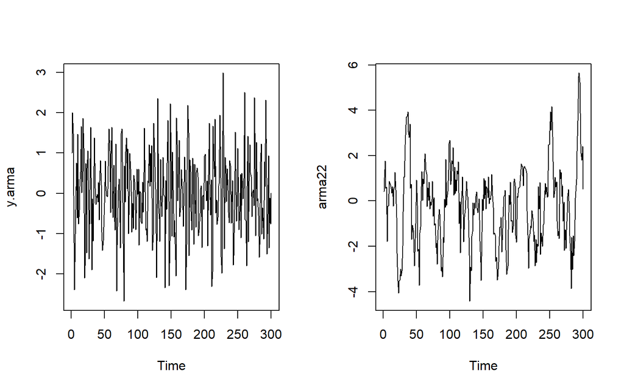

```r
par(mfrow = c(1, 2))
ts.plot(y.arma)
ts.plot(arma22)
```

Berdasarkan plot time series tersebut, terlihat bahwa model ARMA(2,2) cenderung stasioner dalam rataan

```r
par(mfrow = c(1, 1))
```

## Plot ACF

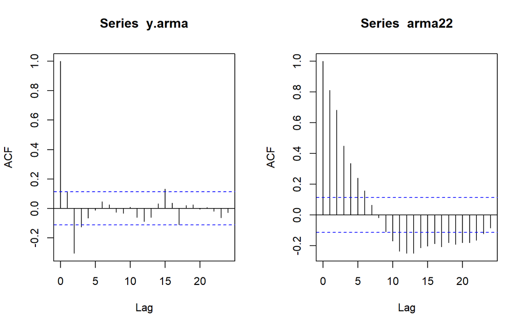

```r
par(mfrow = c(1, 2))
acf(y.arma)
acf(arma22)
```

```r
par(mfrow = c(1, 1))
```

## Plot PACF

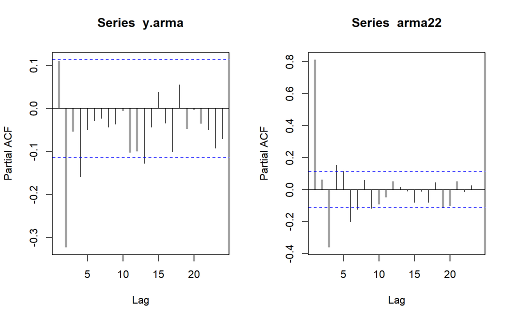

```r
par(mfrow = c(1, 2))
pacf(y.arma)
pacf(arma22)
```

Berdasarkan plot PACF tersebut, terlihat bahwa model ARMA(2,2) baik hasil simulasi maupun dengan pembangkitan fungsi memiliki plot PACF yang *tails off*

```r
par(mfrow = c(1, 1))
```

## Plot EACF

```r
TSA::eacf(y.arma)
```

```
## AR/MA
##   0 1 2 3 4 5 6 7 8 9 10 11 12 13
## 0 o x x o o o o o o o o  o  o  o
## 1 x x o o o o o o o o o  o  o  o
## 2 x x x o o o o o o o o  o  o  o
## 3 x x x x o o o o o o o  o  o  o
## 4 x o o x o o o o o o o  o  o  o
## 5 x o o o o o o o o o o  o  o  o
## 6 x o o x o o o o o o o  o  o  o
## 7 x x x o o o o o o o o  o  o  o
```

```r
TSA::eacf(arma22)
```

```
## AR/MA
##   0 1 2 3 4 5 6 7 8 9 10 11 12 13
## 0 x x x x x x o o o x x  x  x  x
## 1 o x x o o x o o o o x  o  o  o
## 2 x x o o o o o o o o x  o  o  o
## 3 x x o o o o o o o o o  o  o  o
## 4 x x x o x o o o o o o  o  o  o
## 5 x x x x x x o o o o o  o  o  o
## 6 x x x x x o o o o o o  o  o  o
## 7 x x x x x o o o o o o  o  o  o
```

Berdasarkan pola segitiga nol pada plot EACF, terlihat bahwa segitiga nol berada pada ordo AR(1) dan ordo MA(2)

## Scatterplot Antar Lag

### Korelasi antara $Y_t$ dengan $Y_{t-1}$

```r
yt_arma <- y.arma[-1]
yt_arma
```

```
##   [1]  2.000000000  1.486826210 -0.053321783 -2.395295754 -1.011549897
##   [6] -0.403476588  0.750789526 -0.609896886  1.466989524 -0.759290457
##  [11] -0.415227100  0.166745839  0.526729476  1.662668128  0.015910995
##  [16]  0.542215166  1.862754731  1.127930017 -2.101448229 -1.796548361
##  [21]  0.738269602 -1.472731979  0.616027268  1.050232216 -0.410754638
##  [26] -1.628824280  0.090040295  1.639153029  0.388520197 -1.896356404
##  [31] -0.131742880 -1.183213030  0.674932109  1.380475518  0.127415795
##  [36] -0.280513605 -0.103237929 -0.020379961 -0.217478717  0.269280082
##  [41] -0.658436762  0.311573401  0.813747961  0.207565869 -0.960588984
##  [46] -1.415673055 -1.169124822 -0.841024255 -0.231072204  0.800865174
##  [51]  0.178168144 -0.050269390 -0.088938101  0.106319556  1.248971126
##  [56]  1.597926399  1.052622929 -0.478504945  0.985345687  1.637705556
##  [61] -0.381611698 -0.596734083  0.698212663 -0.697103837 -0.907618744
##  [66]  1.224651807 -2.418457048 -1.279718627 -0.371312425  0.073426418
##  [71]  0.359486459 -0.714612352 -1.357174367  1.483796686  1.601232986
```

[output cut: 45 more lines]

```r
yt_1_arma <- y.arma[-300]
yt_1_arma
```

```
##   [1]  1.000000000  2.000000000  1.486826210 -0.053321783 -2.395295754
##   [6] -1.011549897 -0.403476588  0.750789526 -0.609896886  1.466989524
##  [11] -0.759290457 -0.415227100  0.166745839  0.526729476  1.662668128
##  [16]  0.015910995  0.542215166  1.862754731  1.127930017 -2.101448229
##  [21] -1.796548361  0.738269602 -1.472731979  0.616027268  1.050232216
##  [26] -0.410754638 -1.628824280  0.090040295  1.639153029  0.388520197
##  [31] -1.896356404 -0.131742880 -1.183213030  0.674932109  1.380475518
##  [36]  0.127415795 -0.280513605 -0.103237929 -0.020379961 -0.217478717
##  [41]  0.269280082 -0.658436762  0.311573401  0.813747961  0.207565869
##  [46] -0.960588984 -1.415673055 -1.169124822 -0.841024255 -0.231072204
##  [51]  0.800865174  0.178168144 -0.050269390 -0.088938101  0.106319556
##  [56]  1.248971126  1.597926399  1.052622929 -0.478504945  0.985345687
##  [61]  1.637705556 -0.381611698 -0.596734083  0.698212663 -0.697103837
##  [66] -0.907618744  1.224651807 -2.418457048 -1.279718627 -0.371312425
##  [71]  0.073426418  0.359486459 -0.714612352 -1.357174367  1.483796686
```

[output cut: 45 more lines]

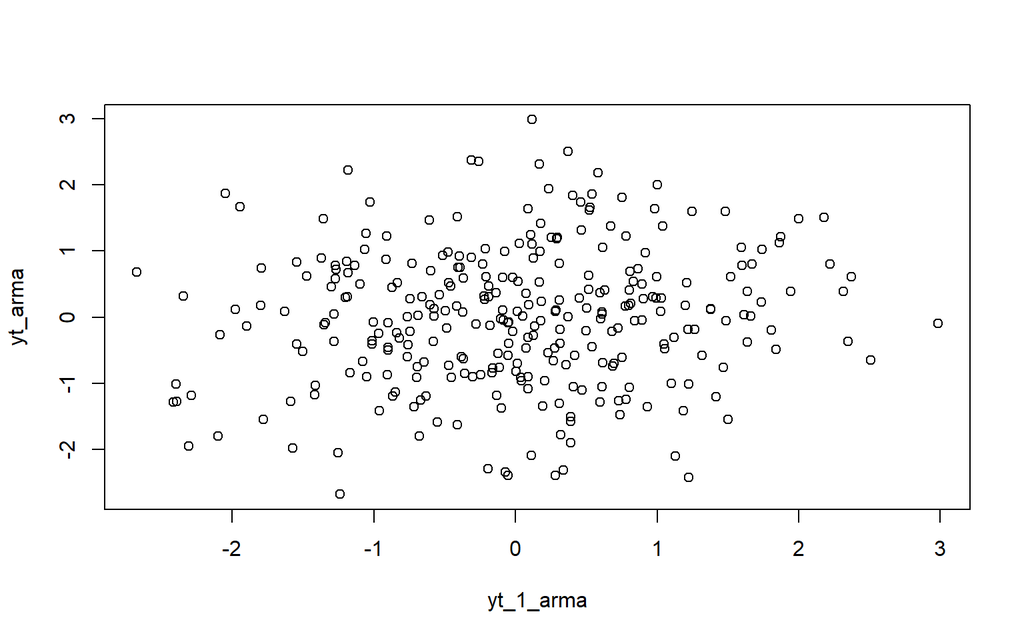

```r
plot(y=yt_arma,x=yt_1_arma)
```

Berdasarkan scatterplot tersebut, terlihat bahwa terdapat hubungan positif antara $Y_t$ dengan $Y_{t-1}$.

```r
cor(yt_arma,yt_1_arma)
```

```
## [1] 0.1105697
```

Korelasi antara $Y_t$ dengan $Y_{t-1}$ dari hasil simulasi jauh berbeda dengan teori, jika berdasarkan teori:

$$\rho_1 = \frac{(1 - \phi_2)\theta_1 + (\phi_1 - \phi_2)\theta_2 +
\phi_1(1 + \theta_1^2 + \theta_2^2)}
{(1 - \phi_2)(1 + \theta_1^2 + \theta_2^2) + 2(\phi_1 -
\phi_2)\theta_1\theta_2}
= \frac{(1 - 0.2)(0.4) + (0.5 - 0.2)(0.6) + 0.5(1 + 0.4^2 + 0.6^2)}
{(1 - 0.2)(1 + 0.4^2 + 0.6^2) + 2(0.5 - 0.2)(0.4)(0.6)}
= \frac{1.26}{1.36} \approx 0.926$$

### Korelasi antara $Y_t$ dengan $Y_{t-2}$

```r
yt_arma <- y.arma[-c(1,2)]
yt_arma
```

```
##   [1]  1.486826210 -0.053321783 -2.395295754 -1.011549897 -0.403476588
##   [6]  0.750789526 -0.609896886  1.466989524 -0.759290457 -0.415227100
##  [11]  0.166745839  0.526729476  1.662668128  0.015910995  0.542215166
##  [16]  1.862754731  1.127930017 -2.101448229 -1.796548361  0.738269602
##  [21] -1.472731979  0.616027268  1.050232216 -0.410754638 -1.628824280
##  [26]  0.090040295  1.639153029  0.388520197 -1.896356404 -0.131742880
##  [31] -1.183213030  0.674932109  1.380475518  0.127415795 -0.280513605
##  [36] -0.103237929 -0.020379961 -0.217478717  0.269280082 -0.658436762
##  [41]  0.311573401  0.813747961  0.207565869 -0.960588984 -1.415673055
##  [46] -1.169124822 -0.841024255 -0.231072204  0.800865174  0.178168144
##  [51] -0.050269390 -0.088938101  0.106319556  1.248971126  1.597926399
##  [56]  1.052622929 -0.478504945  0.985345687  1.637705556 -0.381611698
##  [61] -0.596734083  0.698212663 -0.697103837 -0.907618744  1.224651807
##  [66] -2.418457048 -1.279718627 -0.371312425  0.073426418  0.359486459
##  [71] -0.714612352 -1.357174367  1.483796686  1.601232986  0.781520796
```

[output cut: 45 more lines]

```r
yt_2_arma <- y.arma[-c(299,300)]
yt_2_arma
```

```
##   [1]  1.000000000  2.000000000  1.486826210 -0.053321783 -2.395295754
##   [6] -1.011549897 -0.403476588  0.750789526 -0.609896886  1.466989524
##  [11] -0.759290457 -0.415227100  0.166745839  0.526729476  1.662668128
##  [16]  0.015910995  0.542215166  1.862754731  1.127930017 -2.101448229
##  [21] -1.796548361  0.738269602 -1.472731979  0.616027268  1.050232216
##  [26] -0.410754638 -1.628824280  0.090040295  1.639153029  0.388520197
##  [31] -1.896356404 -0.131742880 -1.183213030  0.674932109  1.380475518
##  [36]  0.127415795 -0.280513605 -0.103237929 -0.020379961 -0.217478717
##  [41]  0.269280082 -0.658436762  0.311573401  0.813747961  0.207565869
##  [46] -0.960588984 -1.415673055 -1.169124822 -0.841024255 -0.231072204
##  [51]  0.800865174  0.178168144 -0.050269390 -0.088938101  0.106319556
##  [56]  1.248971126  1.597926399  1.052622929 -0.478504945  0.985345687
##  [61]  1.637705556 -0.381611698 -0.596734083  0.698212663 -0.697103837
##  [66] -0.907618744  1.224651807 -2.418457048 -1.279718627 -0.371312425
##  [71]  0.073426418  0.359486459 -0.714612352 -1.357174367  1.483796686
```

[output cut: 45 more lines]

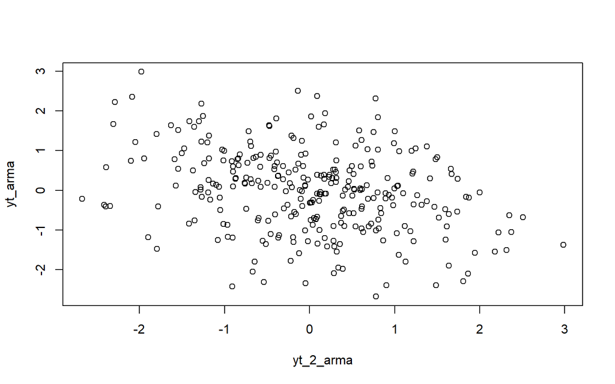

```r
plot(y=yt_arma,x=yt_2_arma)
```

Berdasarkan scatterplot tersebut, terlihat bahwa terdapat hubungan negatif antara $Y_t$ dengan $Y_{t-2}$.

```r
cor(yt_arma,yt_2_arma)
```

```
## [1] -0.308692
```

Nilai korelasi antara $Y_t$ dengan $Y_{t-2}$ dari hasil simulasi jauh berbeda dengan teori, jika berdasarkan teori:

$$\rho_2 = \frac{(\phi_1 + \theta_1\theta_2)(1 - \phi_2) + (\phi_1^2 -
\phi_2)(1 + \theta_1^2 + \theta_2^2) + \theta_2(\theta_1 +
\phi_1\theta_2)}
{(1 - \phi_2)(1 + \theta_1^2 + \theta_2^2) + 2(\phi_1 -
\phi_2)\theta_1\theta_2}
= \frac{(0.5 + 0.4 \times 0.6)(0.8) + (0.5^2 - 0.2)(1 + 0.4^2 + 0.6^2) +
0.6(0.4 + 0.5 \times 0.6)}
{(1-0.2)(1 + 0.4^2 + 0.6^2) + 2(0.5 - 0.2)(0.4)(0.6)}
= \frac{1.088}{1.36} = 0.8$$

### Korelasi antara $Y_t$ dengan $Y_{t-3}$

```r
yt_arma <- y.arma[-c(1,2,3)]
yt_arma
```

```
##   [1] -0.053321783 -2.395295754 -1.011549897 -0.403476588  0.750789526
##   [6] -0.609896886  1.466989524 -0.759290457 -0.415227100  0.166745839
##  [11]  0.526729476  1.662668128  0.015910995  0.542215166  1.862754731
##  [16]  1.127930017 -2.101448229 -1.796548361  0.738269602 -1.472731979
##  [21]  0.616027268  1.050232216 -0.410754638 -1.628824280  0.090040295
##  [26]  1.639153029  0.388520197 -1.896356404 -0.131742880 -1.183213030
##  [31]  0.674932109  1.380475518  0.127415795 -0.280513605 -0.103237929
##  [36] -0.020379961 -0.217478717  0.269280082 -0.658436762  0.311573401
##  [41]  0.813747961  0.207565869 -0.960588984 -1.415673055 -1.169124822
##  [46] -0.841024255 -0.231072204  0.800865174  0.178168144 -0.050269390
##  [51] -0.088938101  0.106319556  1.248971126  1.597926399  1.052622929
##  [56] -0.478504945  0.985345687  1.637705556 -0.381611698 -0.596734083
##  [61]  0.698212663 -0.697103837 -0.907618744  1.224651807 -2.418457048
##  [66] -1.279718627 -0.371312425  0.073426418  0.359486459 -0.714612352
##  [71] -1.357174367  1.483796686  1.601232986  0.781520796 -1.237985145
```

[output cut: 45 more lines]

```r
yt_3_arma <- y.arma[-c(298,299,300)]
yt_3_arma
```

```
##   [1]  1.000000000  2.000000000  1.486826210 -0.053321783 -2.395295754
##   [6] -1.011549897 -0.403476588  0.750789526 -0.609896886  1.466989524
##  [11] -0.759290457 -0.415227100  0.166745839  0.526729476  1.662668128
##  [16]  0.015910995  0.542215166  1.862754731  1.127930017 -2.101448229
##  [21] -1.796548361  0.738269602 -1.472731979  0.616027268  1.050232216
##  [26] -0.410754638 -1.628824280  0.090040295  1.639153029  0.388520197
##  [31] -1.896356404 -0.131742880 -1.183213030  0.674932109  1.380475518
##  [36]  0.127415795 -0.280513605 -0.103237929 -0.020379961 -0.217478717
##  [41]  0.269280082 -0.658436762  0.311573401  0.813747961  0.207565869
##  [46] -0.960588984 -1.415673055 -1.169124822 -0.841024255 -0.231072204
##  [51]  0.800865174  0.178168144 -0.050269390 -0.088938101  0.106319556
##  [56]  1.248971126  1.597926399  1.052622929 -0.478504945  0.985345687
##  [61]  1.637705556 -0.381611698 -0.596734083  0.698212663 -0.697103837
##  [66] -0.907618744  1.224651807 -2.418457048 -1.279718627 -0.371312425
##  [71]  0.073426418  0.359486459 -0.714612352 -1.357174367  1.483796686
```

[output cut: 45 more lines]

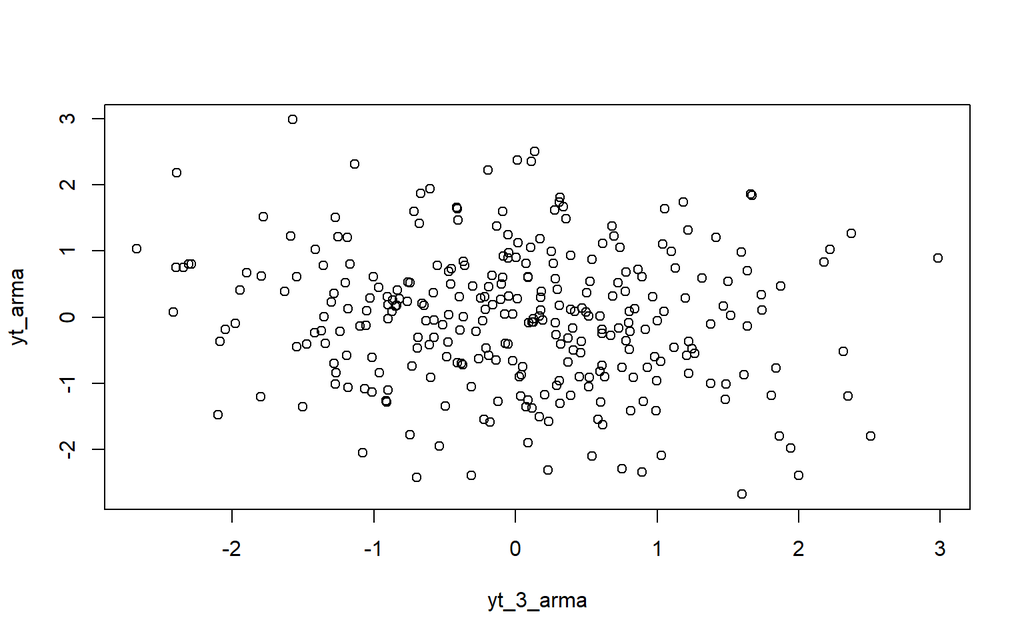

```r
plot(y=yt_arma,x=yt_3_arma)
```

Berdasarkan scatterplot tersebut, terlihat bahwa terdapat hubungan negatif antara $Y_t$ dengan $Y_{t-3}$.

```r
cor(yt_arma,yt_3_arma)
```

```
## [1] -0.1286886
```

Nilai korelasi antara $Y_t$ dengan $Y_{t-2}$ dari hasil simulasi jauh berbeda dengan teori, jika berdasarkan teori:

$$\rho_3 = \phi_1 \rho_2 + \phi_2 \rho_1
= (0.5)(0.8) + (0.2)(0.926)
= 0.5852$$